# Context

This report was created as part of an assignment in STAT5002 at University of Sydney. The report provides a linear regression analysis into few of the variables present in the ames housing dataset and finds a best fit for the data. The accompanying assignment questions can be found on my github @KiranmayiV/data-science-portfolio/AmesHousing Assignment.

```r
data_url='/Users/kiran/Documents/mywork/portfolio/datascience/AmesHousing Assignment/AmesHousing_num.csv'
AmesHousing_num_csv=read.csv(data_url, header=TRUE)
remove(data_url)
data <- AmesHousing_num_csv
require(dplyr)
library(GGally)
```

```r
#a) probability of house having basement
houses=nrow(AmesHousing_num_csv)
houses_nb=sum(is.na(AmesHousing_num_csv['Bsmt.Qual']))
1-houses_nb/houses
```

```
## [1] 0.9730375
```

```r
#b) probability of house having a pool
houses_np=sum(is.na(AmesHousing_num_csv['Pool.QC']))
1-houses_np/houses
```

```
## [1] 0.00443686
```

```r
#c) probability of house having both pool and basement
poolBase=sum(is.na(AmesHousing_num_csv['Bsmt.Qual'])==FALSE & is.na(AmesHousing_num_csv['Pool.QC'])==FALSE)
poolBase/houses
```

```
## [1] 0.004095563
```

###### Question 2: Exploring linear fit models

Considering these 4 models, I will explore which of these models captures maximum variation in the y variable. $Yij = \beta_0+\beta_1x_{1i}+\epsilon_{ij}$(1)

$log(Yij) = \beta_0 + \beta_1x_{1i} + \epsilon_{ij}$(2)

$Yij = \beta_0 + \beta_1log(x_{1i}) + \epsilon_{ij}$(3)

$log(Yij) = \beta_0 + \beta_1log(x_{1i}) + \epsilon_{ij}$(4)

Scatter plots:

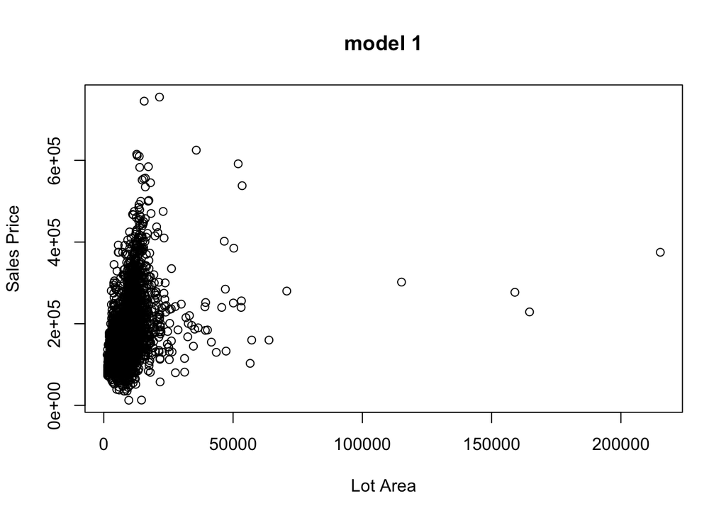

```r
plot(AmesHousing_num_csv$Lot.Area, AmesHousing_num_csv$SalePrice, xlab = "Lot Area", ylab = "Sales Price", main = "model 1" )
```

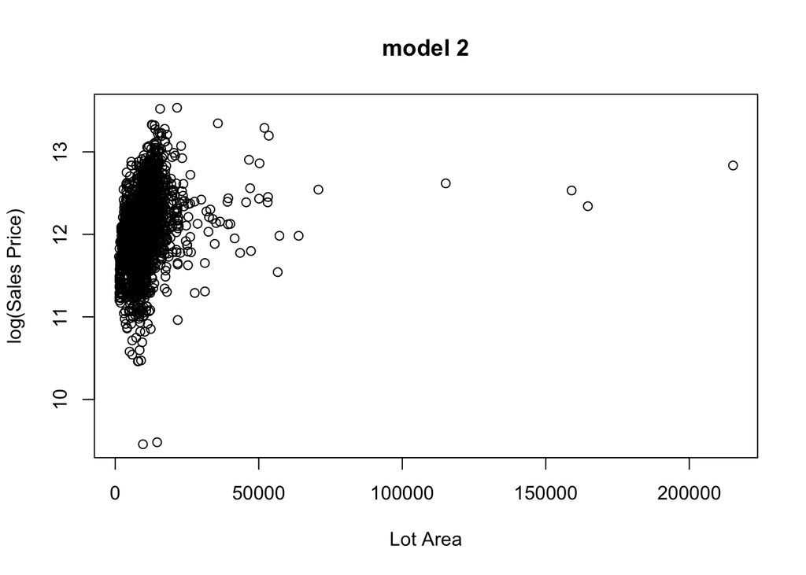

```r
plot(AmesHousing_num_csv$Lot.Area, log(AmesHousing_num_csv$SalePrice),xlab = "Lot Area", ylab = "log(Sales Price)", main = "model 2" )
```

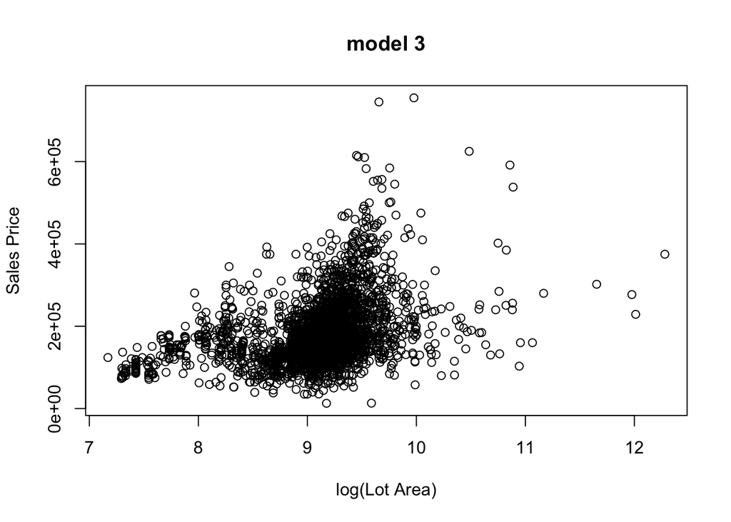

```r
plot(log(AmesHousing_num_csv$Lot.Area), (AmesHousing_num_csv$SalePrice),xlab = "log(Lot Area)", ylab = "Sales Price", main = "model 3")
```

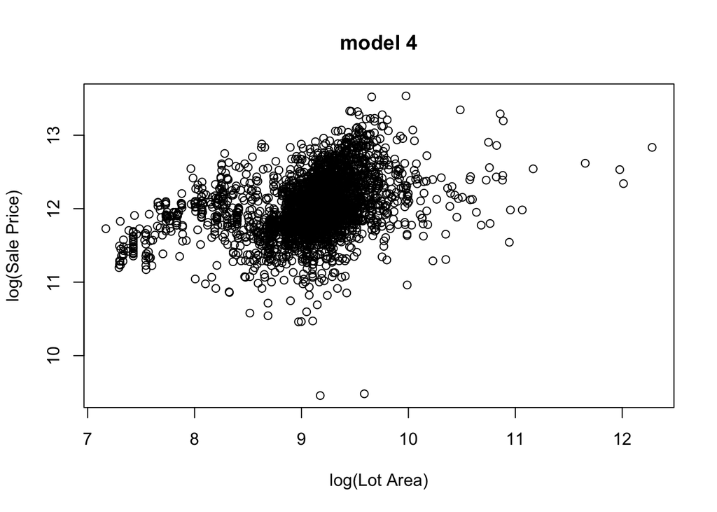

```r
plot(log(AmesHousing_num_csv$Lot.Area),log(AmesHousing_num_csv$SalePrice), xlab = "log(Lot Area)", ylab = "log(Sale Price)", main = "model 4")
```

Based on just visual inspection, log(Sale Price) vs log(Lot area) shows visible linear relationship.

We now plot boxplots to check for outliers.

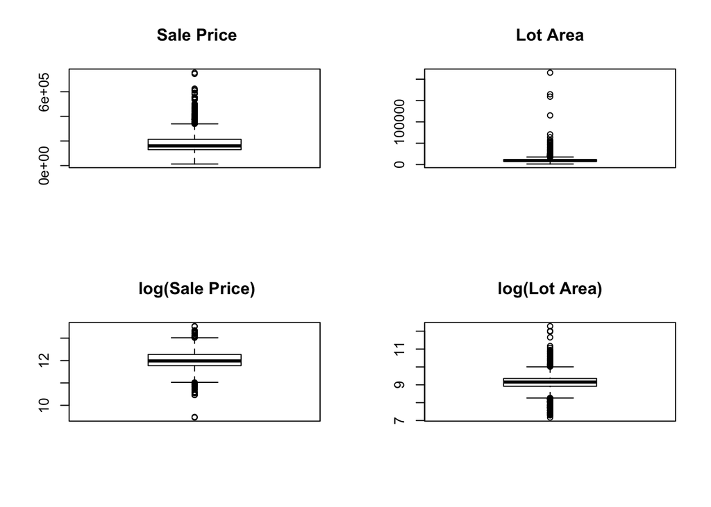

```r
par(mfrow=c(2, 2))  # divide graph area in 2 columns
boxplot(AmesHousing_num_csv$SalePrice , main=" Sale Price")

boxplot(AmesHousing_num_csv$Lot.Area, main="Lot Area")

boxplot(log(AmesHousing_num_csv$SalePrice) , main=" log(Sale Price)")

boxplot(log(AmesHousing_num_csv$Lot.Area), main="log(Lot Area)")
```

Since the Sale prince and Lot Area both have several outliers, the linear regression model would not be a good model for making predictions.

Examining density plots gives an idea into normality of the variables.

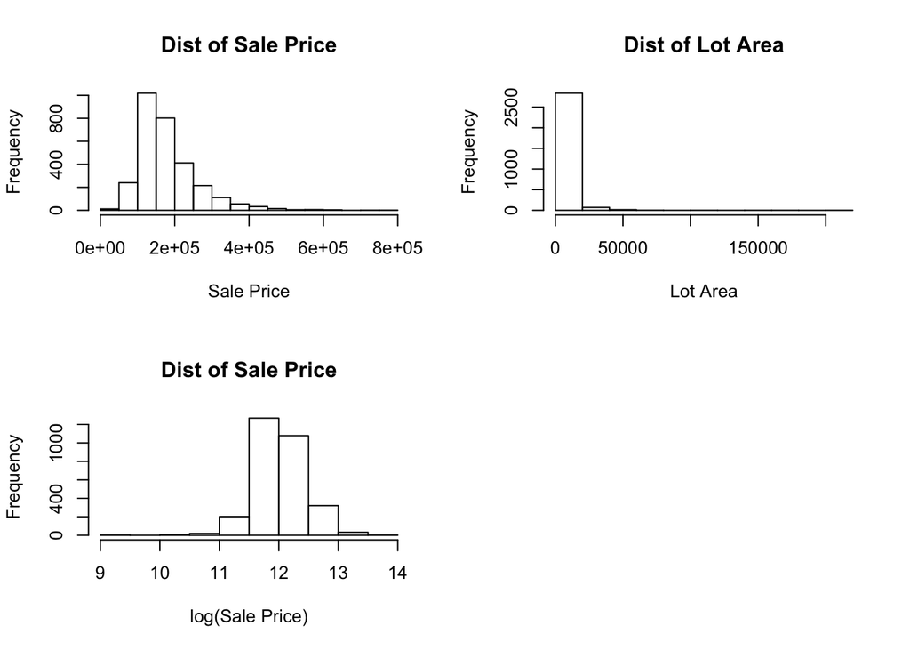

```r
par(mfrow=c(2, 2))
hist(AmesHousing_num_csv$SalePrice, main = "Dist of Sale Price", xlab = "Sale Price")
hist(AmesHousing_num_csv$Lot.Area, main = "Dist of Lot Area", xlab = "Lot Area")

hist(log(AmesHousing_num_csv$SalePrice), main = "Dist of Sale Price", xlab = "log(Sale Price)")
```

Investigating now correlation coefficients.

```r
cor(data$Lot.Area,data$SalePrice)
```

```
## [1] 0.2665492
```

```r
cor(data$Lot.Area,log(data$SalePrice))
```

```
## [1] 0.2550314
```

```r
cor(log(data$Lot.Area),data$SalePrice)
```

```
## [1] 0.365076
```

```r
cor(log(data$Lot.Area),log(data$SalePrice))
```

```
## [1] 0.3684939
```

Performing Simple Linear Regression Analysis and examining for best fit.

```r
model1 = lm(data$SalePrice ~ 1 + data$Lot.Area)
model2 = lm(log(data$SalePrice) ~ 1 + data$Lot.Area)
model3 = lm(data$SalePrice ~ 1 + log(data$Lot.Area))
model4 = lm(log(data$SalePrice) ~ 1 + log(data$Lot.Area))
summary(model1)
```

```
##
## Call:
## lm(formula = data$SalePrice ~ 1 + data$Lot.Area)
##
## Residuals:
##     Min      1Q  Median      3Q     Max
## -369375  -47827  -18982   31261  549409
##
## Coefficients:
##                Estimate Std. Error t value Pr(>|t|)
## (Intercept)   1.534e+05  2.320e+03   66.11   <2e-16 ***
## data$Lot.Area 2.702e+00  1.806e-01   14.96   <2e-16 ***
## ---
## Signif. codes:  0 '***' 0.001 '**' 0.01 '*' 0.05 '.' 0.1 ' ' 1
##
## Residual standard error: 77010 on 2928 degrees of freedom
## Multiple R-squared:  0.07105,    Adjusted R-squared:  0.07073
## F-statistic: 223.9 on 1 and 2928 DF,  p-value: < 2.2e-16
```

```r
summary(model2)
```

```
##
## Call:
## lm(formula = log(data$SalePrice) ~ 1 + data$Lot.Area)
##
## Residuals:
##      Min       1Q   Median       3Q      Max
## -2.59912 -0.23301 -0.03129  0.24270  1.42795
##
## Coefficients:
##                Estimate Std. Error t value Pr(>|t|)
## (Intercept)   1.189e+01  1.187e-02 1001.06   <2e-16 ***
## data$Lot.Area 1.319e-05  9.243e-07   14.27   <2e-16 ***
## ---
## Signif. codes:  0 '***' 0.001 '**' 0.01 '*' 0.05 '.' 0.1 ' ' 1
##
## Residual standard error: 0.3942 on 2928 degrees of freedom
## Multiple R-squared:  0.06504,    Adjusted R-squared:  0.06472
## F-statistic: 203.7 on 1 and 2928 DF,  p-value: < 2.2e-16
```

```r
summary(model3)
```

```
##
## Call:
## lm(formula = data$SalePrice ~ 1 + log(data$Lot.Area))
##
## Residuals:
##     Min      1Q  Median      3Q     Max
## -195967  -48146  -17408   34446  532007
##
## Coefficients:
##                    Estimate Std. Error t value Pr(>|t|)
## (Intercept)         -337991      24488  -13.80   <2e-16 ***
## log(data$Lot.Area)    57058       2689   21.22   <2e-16 ***
## ---
## Signif. codes:  0 '***' 0.001 '**' 0.01 '*' 0.05 '.' 0.1 ' ' 1
##
## Residual standard error: 74390 on 2928 degrees of freedom
## Multiple R-squared:  0.1333, Adjusted R-squared:  0.133
## F-statistic: 450.3 on 1 and 2928 DF,  p-value: < 2.2e-16
```

```r
summary(model4)
```

```
##
## Call:
## lm(formula = log(data$SalePrice) ~ 1 + log(data$Lot.Area))
##
## Residuals:
##      Min       1Q   Median       3Q      Max
## -2.68619 -0.22847 -0.02993  0.24789  1.33436
##
## Coefficients:
##                    Estimate Std. Error t value Pr(>|t|)
## (Intercept)          9.3493     0.1248   74.94   <2e-16 ***
## log(data$Lot.Area)   0.2938     0.0137   21.45   <2e-16 ***
## ---
## Signif. codes:  0 '***' 0.001 '**' 0.01 '*' 0.05 '.' 0.1 ' ' 1
##
## Residual standard error: 0.379 on 2928 degrees of freedom
## Multiple R-squared:  0.1358, Adjusted R-squared:  0.1355
## F-statistic: 460.1 on 1 and 2928 DF,  p-value: < 2.2e-16
```

Performing Model Diagnostics: (a) Residuals

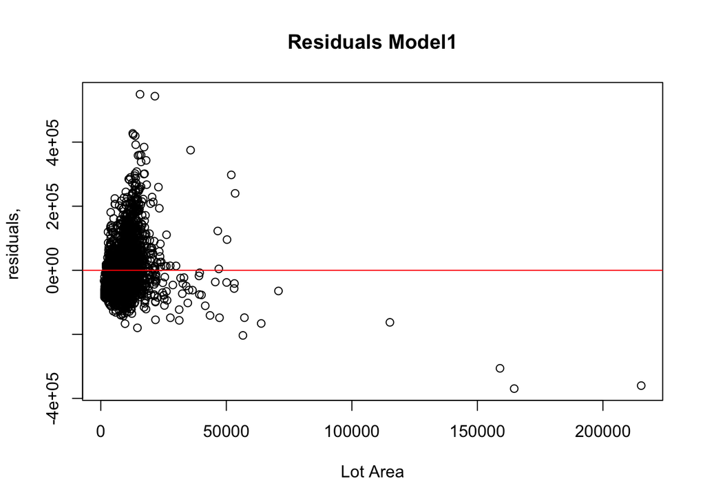

```r
plot(data$Lot.Area ,model1$residuals, xlab= "Lot Area", ylab = "residuals, ", main = "Residuals Model1")
abline(h=0, col= "red")
```

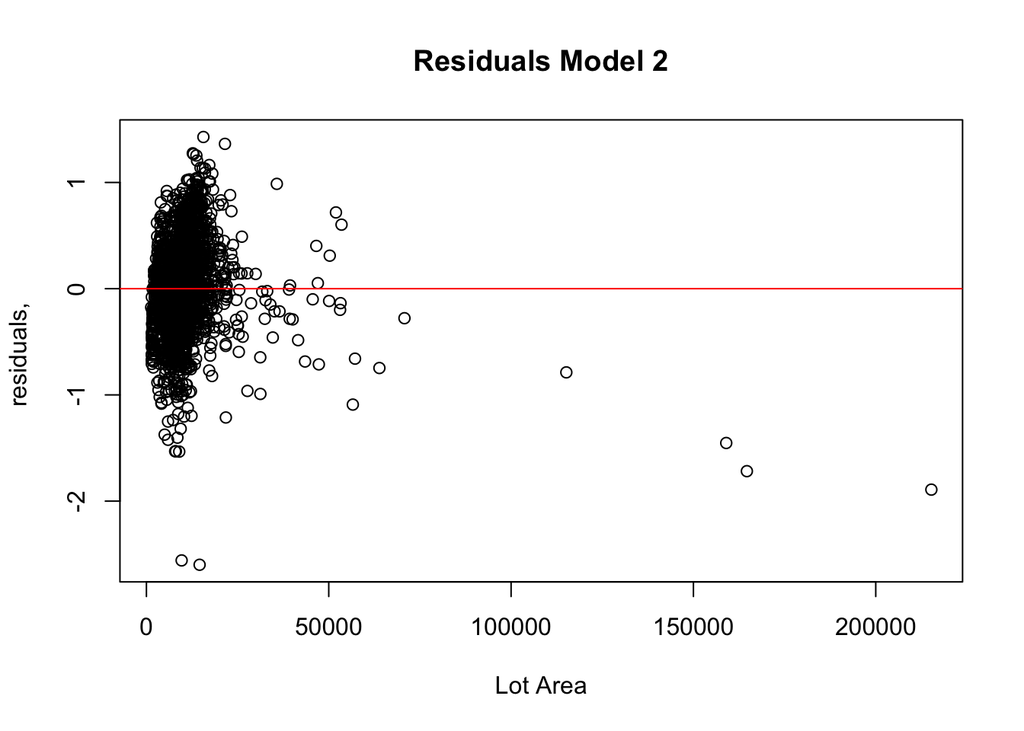

```r
plot(data$Lot.Area,model2$residuals, xlab= "Lot Area", ylab = "residuals, ", main = "Residuals Model 2")
abline(h=0, col= "red")
```

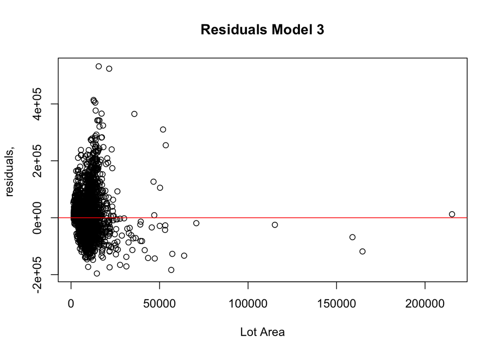

```r
plot(data$Lot.Area,model3$residuals, xlab= "Lot Area", ylab = "residuals, ", main = "Residuals Model 3")
abline(h=0, col= "red")
```

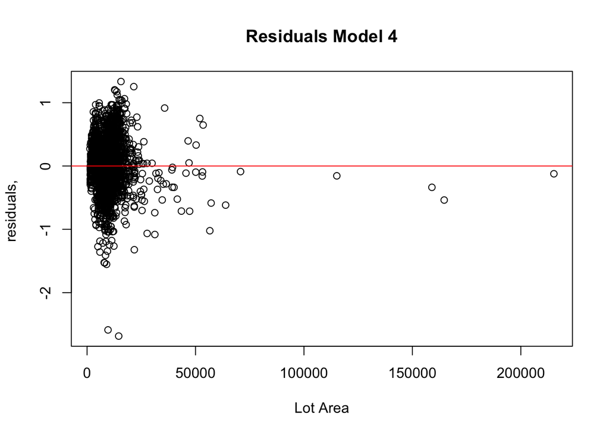

```r
plot(data$Lot.Area,model4$residuals, xlab= "Lot Area", ylab = "residuals, ", main = "Residuals Model 4")
abline(h=0, col= "red")
```

2. Calculating Pearson’s Sample Correlation Coefficient (r) and Coefficient of Determination (r^2)

```r
#model 1
cor(data$Lot.Area,data$SalePrice)^2
```

```
## [1] 0.07104849
```

```r
#model 2
cor(data$Lot.Area,log(data$SalePrice))^2
```

```
## [1] 0.06504103
```

```r
#model 3
cor(log(data$Lot.Area),data$SalePrice)^2
```

```
## [1] 0.1332805
```

```r
#model 4
cor(log(data$Lot.Area),log(data$SalePrice))^2
```

```
## [1] 0.1357878
```

3. Further we can see how the the fitted line on the scatter plots:

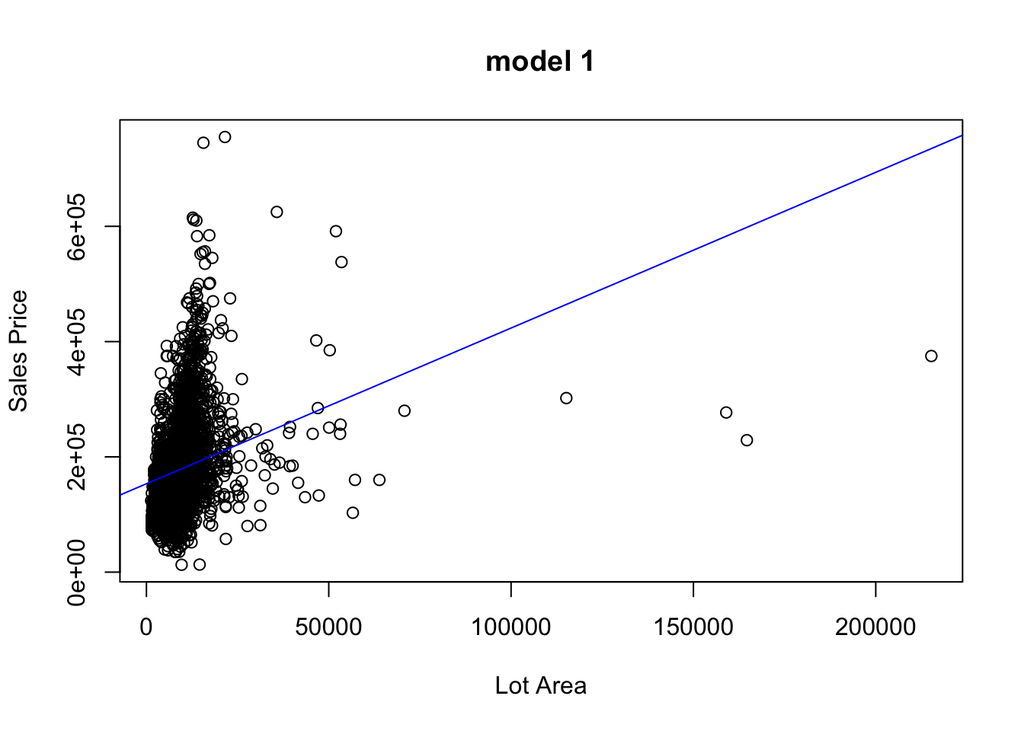

```r
plot(data$Lot.Area, data$SalePrice,xlab = "Lot Area", ylab = "Sales Price", main = "model 1" )
abline(model1$coefficients, col ="blue")
```

[figure not shown]

```r
plot(log(data$Lot.Area), data$SalePrice,xlab = "Lot Area", ylab = "log(Sales Price)", main = "model 2" )
abline(model2$coefficients, col ="blue")
```

[figure not shown]

```r
plot(data$Lot.Area, log(data$SalePrice),xlab = "log(Lot Area)", ylab = "Sales Price", main = "model 3" )
abline(model3$coefficients, col ="blue")
```

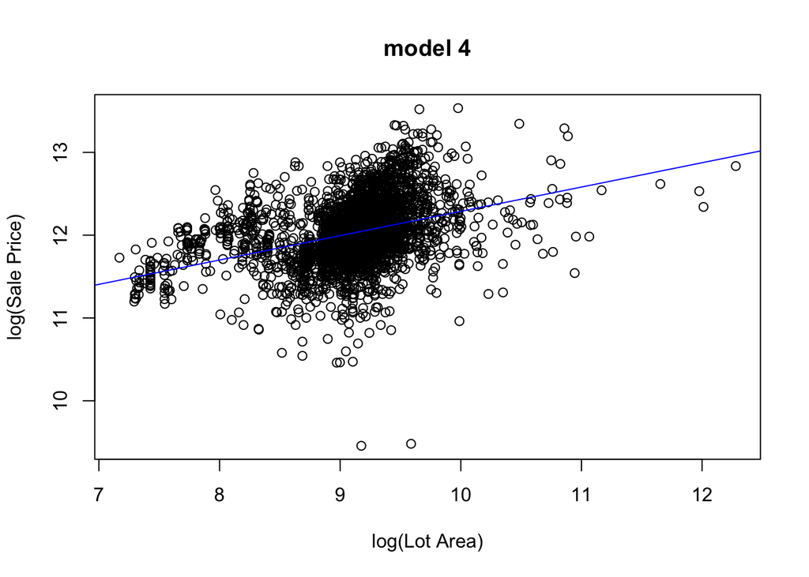

```r
plot(log(data$Lot.Area),log(data$SalePrice), xlab = "log(Lot Area)", ylab = "log(Sale Price)", main = "model 4")
abline(model4$coefficients, col ="blue")
```

Based on the above diagnostics, we concluded model 4 is the best fit for the given data.

###### Question 2b

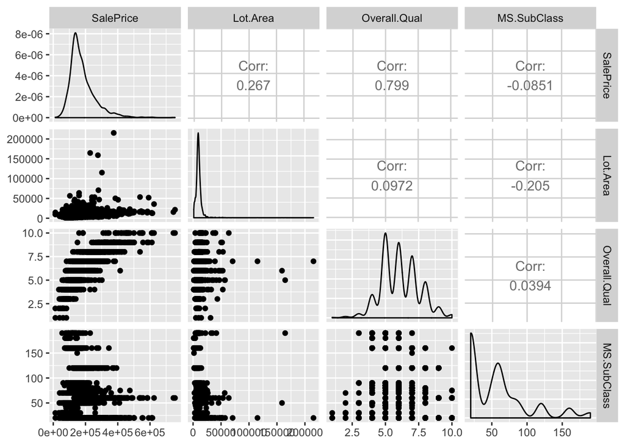

```r
dat2 = select(AmesHousing_num_csv, SalePrice, Lot.Area, Overall.Qual, MS.SubClass)
#round(cor(dat2),2)
#pairs(dat2)

ggpairs(dat2)
```

###### Question2c

Question 2c (i)

```r
model=lm(log(data$SalePrice) ~ 1 + data$Lot.Area + AmesHousing_num_csv$Overall.Qual + AmesHousing_num_csv$MS.SubClass)
summary(model)
```

```
##
## Call:
## lm(formula = log(data$SalePrice) ~ 1 + data$Lot.Area + AmesHousing_num_csv$Overall.Qual +
##     AmesHousing_num_csv$MS.SubClass)
##
## Residuals:
##      Min       1Q   Median       3Q      Max
## -1.61750 -0.11961  0.01446  0.12979  0.86829
##
## Coefficients:
##                                    Estimate Std. Error t value Pr(>|t|)
## (Intercept)                       1.054e+01  1.895e-02 556.531  < 2e-16
## data$Lot.Area                     8.369e-06  5.226e-07  16.015  < 2e-16
## AmesHousing_num_csv$Overall.Qual  2.347e-01  2.859e-03  82.114  < 2e-16
## AmesHousing_num_csv$MS.SubClass  -6.660e-04  9.619e-05  -6.924 5.39e-12
##
## (Intercept)                      ***
## data$Lot.Area                    ***
## AmesHousing_num_csv$Overall.Qual ***
## AmesHousing_num_csv$MS.SubClass  ***
## ---
## Signif. codes:  0 '***' 0.001 '**' 0.01 '*' 0.05 '.' 0.1 ' ' 1
##
## Residual standard error: 0.2169 on 2926 degrees of freedom
## Multiple R-squared:  0.7172, Adjusted R-squared:  0.7169
## F-statistic:  2473 on 3 and 2926 DF,  p-value: < 2.2e-16
```

```r
out=(cooks.distance(model) >= 1)
#which points
AmesHousing_num_csv$SalePrice[out=="TRUE"]
```

```
## [1] 375000
```

```r
AmesHousing_num_csv$`Lot Area`[out=="TRUE"]
## NULL
AmesHousing_num_csv$`Overall Qual`[out=="TRUE"]
## NULL
#number of high leverage points
lev=lm.influence(model)$h>2*3/2930
length(AmesHousing_num_csv$SalePrice[lev="TRUE"])
```

```
## [1] 1
```

```r
AmesHousing_num_csv$SalePrice[lev="TRUE"]
```

```
## [1] NA
```

Q2 (c)(iii)

```r
lot.area= 10000
qual=9
loggedSP=model$coefficients[1] + model$coefficients[2]*lot.area + model$coefficients[3]*qual
```